# miWQS: Multiple Imputation Using Weighted Quantile Sum Regression

Paul M. Hargarten

Virginia Commonwealth University

David C. Wheeler

Virginia Commonwealth University

2021-01-14

Abstract

The *miWQS* package in the Comprehensive R Archive Network (CRAN) utilizes weighted quantile sum regression (WQS) in the multiple imputation (MI) framework. The data analyzed is a set/mixture of continuous and correlated components/chemicals that are reasonable to combine in an index and share a common outcome. These components are also interval-censored between zero and upper thresholds, or detection limits, which may differ among the components. This type of data is found in areas such as chemical epidemiological studies, sociology, and genomics. The *miWQS* package can be run using complete or incomplete data, which may be placed in the first quantile, or imputed using bootstrap or Bayesian approach. This article provides a stepwise and hands-on approach to handle uncertainty due to values below the detection limit in correlated component mixture problems.

# Introduction

When studying public health, researchers want to determine if a set/mixture of continuous and correlated components/chemicals is associated with an outcome and if so, which components are important in that mixture (Braun et al. 2016). These components share a common univariate outcome but are interval-censored between zero and low thresholds, or detection limits, that may be different across the components.

We have created the [*miWQS*](https://CRAN.R-project.org/package=miWQS) package to analyze epidemiological studies with chemical exposures, but researchers may also apply the package to public health, genomics, or other areas in public health and medicine. Epidemiologists examine chemical mixtures because human exposure to a large number of chemicals may increase the risk of disease (Braun et al. 2016). Researchers may also create a socioeconomic status (SES) index that is generally composed of continuous correlated variables in the following domains: educational achievement, race, income, housing, and employment (Wheeler, Czarnota, and Jones 2017; Wheeler, Jones, et al. 2019). For example, race may be represented by percent of the population that is white. There are several examples of this in the literature (Wheeler, Raman, et al. 2019; Wheeler et al. 2020). Although these variables may have missing values throughout the distribution, researchers may use the *miWQS* package to create SES index even in the presence of missing data. Alternatively, genome-wide association studies (GWAS’s) analyze DNA sequence variation using single nucleotide polymorphisms (SNPs) (Bush and Moore 2012). As SNPs constitute high-frequency changes of a single base in the DNA sequence throughout the genome, SNPs serve as markers of a genomic region (Bush and Moore 2012). Thus, SNPs are highly correlated (Bush and Moore 2012; Ferber and Archer 2015). The research aim of a GWAS is to find associations between genes and common and complex diseases like schizophrenia and to identify specific associated genes. The *miWQS* package can answer this research aim while simultaneously accounting for the correlation between SNPs.

In the data, an approach to account for the correlation among completely observed components is the weighted quantile sum (WQS) regression (Carrico et al. 2014; Czarnota, Gennings, and Wheeler 2015; Gennings et al. 2013). The application of WQS regression to censored data has been limited statistically and computationally on CRAN (the Comprehensive R Archive Network) (Czarnota et al. 2015; Horton et al. 2015; Czarnota and Wheeler 2015; Renzetti et al. 2020). In order to fully account for the uncertainty due to censoring, the *miWQS* package utilizes WQS regression in the multiple imputation (MI) framework (Hargarten and Wheeler 2020, 2021).

As compared to other WQS packages in R, the *miWQS* package is specifically designed to use highly correlated data that include interval-censoring. The [*wqs*](https://CRAN.R-project.org/package=wqs) (Czarnota and Wheeler 2015) package performs WQS regression only on complete mixtures that share a continuous or binary outcome. The `wqs.est()` function in the *wqs* package can be used for continuous outcomes and displays an error if fed incomplete information. The `gwqs()` function in the [*gWQS*](https://CRAN.R-project.org/package=gWQS) package runs WQS regression when the outcome is continuous, binary, binomial, multinomial, or a count. If incomplete components are inputted into `gwqs()`, the function uses non-missing data without warning (Renzetti et al. 2020). By contrast, the *miWQS* functions are constructed to handle both complete and incomplete mixture data that share a continuous, binary, or count outcome by using MI.

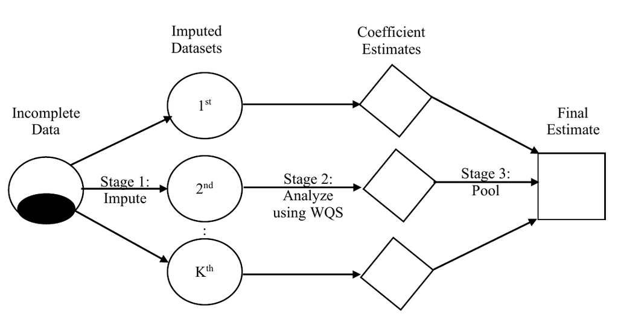

Figure 1: Multiple Imputation in connection with the Weighted Quantile Sum regression (MI-WQS). Given partially observed correlated chemical exposures that share a common outcome and covariates, (stage 1) researchers impute the below detection limit values (dark circles) K times to form complete datasets. In stage 2, each imputed dataset is analyzed using WQS regression. In stage 3, the coefficient estimates from the K WQS regressions (diamonds) are combined into a final estimate (square).

The MI approach provides valid statistical inference in estimating regression parameters when data are missing (Dong and Peng 2013; Rubin 1987; White, Royston, and Wood 2011). Specifically, MI consists of three stages: (1) imputation, (2) analysis, and (3) pooling (Figure 1). First, we create several imputed datasets by replacing the below the detection limit (BDL) values by plausible data values. The complete datasets are identical for the observed data but are different in the imputed values. Second, we analyze each complete dataset using WQS regression to obtain estimates (Carrico et al. 2014; Czarnota, Gennings, and Wheeler 2015; Gennings et al. 2013; Hargarten and Wheeler 2020). Lastly, we combine each WQS estimate from different analyses to form one final estimate, to find its variance, and to perform statistical tests in order to determine the significance of the exposure effects.

Other MI packages in R have functions that combine estimates, but these are different than the `pool.mi()` function used in the *miWQS* package. The [*mice*](https://CRAN.R-project.org/package=mice) (multiple imputation by chained equations) package implements a strategy to impute multivariate missing data using fully conditional densities (van Buuren and Groothuis-Oudshoorn 2011). Its pool function combines one estimate at a time, while `pool.mi()` combines all estimates simultaneously. The [*norm*](https://CRAN.R-project.org/package=norm) package allows users to impute values with an assumed multivariate normal distribution (Novo and Schafer 2013). Its pool function, `mi.inference()`, does not allow the user to adjust the degree of freedom due to small sample sizes in contrast to `pool.mi()`. The [*mi*](https://CRAN.R-project.org/package=mi) package performs multiple imputation with missing values and saves the results as a `mi-class` object (Su et al. 2011). As a `mi-class` object is used to pool estimates inside the *mi* package, we cannot use it to pool estimates obtained in other packages.

Contrasting with the other packages on CRAN, the purpose of the *miWQS* package is to find an association of interval-censored mixture data with an outcome. The *miWQS* package can be run using complete or incomplete data. Incomplete data may be placed in the first quantile of the index or imputed using bootstrap or Bayesian approach. In this vignette, we will discuss how the data are formatted and then answer the research objectives using the *miWQS* package in four different ways: (1) with complete data, (2) with incomplete data placed in the first quantile, (3) with incomplete data imputed by bootstrapping, and (4) with incomplete data by using a Bayesian approach.

# Data structure

This section describes what the data should look like in order to use the *miWQS* package. We wish to assess the association of the mixture of components, $\boldsymbol{X}$, and a univariate outcome, $y$, while accounting for other covariates, $\boldsymbol{Z}$. However, the continuous non-detects in the mixture ($\boldsymbol{X}$) are interval-censored between zero and different detection limits $DL$. Any missing values in the covariates or outcome are ignored and removed before imputation and analysis. Although $\boldsymbol{X}$ may refer to a variable with no obvious $DL$, we consider chemical concentrations $\boldsymbol{X}$ with each being partially observed in this vignette.

After installing the R package *miWQS* from CRAN, load the package and the dataset as follows.

```r
> library("miWQS")
```

```r
Loading required package: parallel
```

```r
> data("simdata87")
```

The numeric components of interest to combine into an index $\boldsymbol{X}$ are stored in a matrix or a data frame. Any missing values in $\boldsymbol{X}$ are denoted by NA’s and are assumed to be censored between zero and an upper threshold, *DL*. The *DL* is a numeric vector, where each element represents the detection limit (DL) for each chemical. In order to use the imputation techniques in *miWQS*, each chemical must have a known DL, or an upper bound. Otherwise, chemical values are placed in the first quantile (BDLQ1) of the weighted index (see Example 2). For instance, 14 non-missing chemical concentrations are saved as columns in a matrix `simdata87$X.true`. The matrix `simdata87$X.bdl` contains these 14 chemical concentrations, but 100 values are subbed as missing for each chemical between zero and different detection limits. These detection limits are saved in element `DL` of `simdata87` and are printed below along with their chemical names.

```r
> simdata87$DL
```

```r
  alpha-chlordane          dieldrin   gamma-chlordane           lindane
        0.9244609         4.4464426        29.1202898         8.2705681
     methoxychlor               dde               ddt pentachlorophenol
       41.3440690         2.3958978         4.5525251         5.1020673
          pcb_105           pcb_118           pcb_138           pcb_153
        1.6490457         1.9822575         1.2512259         0.7401736
          pcb_170           pcb_180
        3.3034084         1.0357342
```

A heat map of the observed logarithmic chemical concentrations (`simdata87$X.bdl`) shows the correlations among the components in our dataset (Figure 2). The *miWQS* package handles such correlated component data to examine whether the mixture is associated with the outcome.

```r
>
> GGally::ggcorr(
+   log(simdata87$X.bdl),
+   method = c("pairwise", "spearman"),
+   geom = "tile",
+   layout.exp = 2,
+   hjust = 0.75,
+   size = 3,
+   legend.position = "bottom"
+ )
```

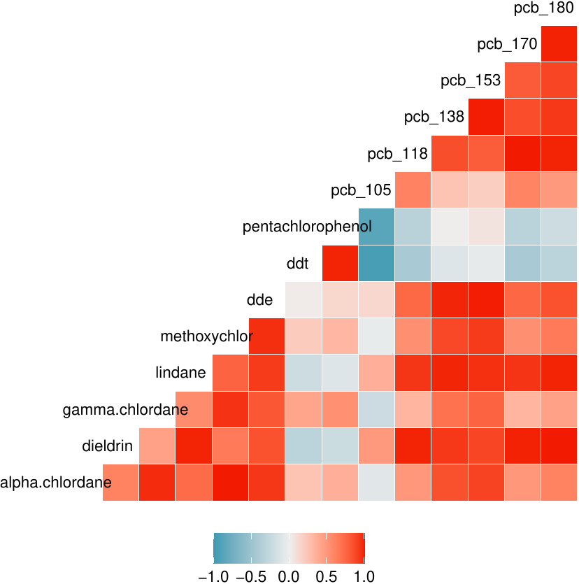

Figure 2: Heat map of the correlations using the fourteen observed chemical logarithmic concentrations in dataset simdata87 can be analyzed with the package miWQS. The heat map was generated using the GGally package.

Chemical exposure patterns often differ between individuals due to demographics and other confounders. The additional covariates $\boldsymbol{Z}$ can be represented as a vector, data frame, or matrix. For example, the element `Z.sim` in the list `simdata87` is a matrix that contains an individual’s age, sex (Female/Male), ethnicity (Hispanic/Non-Hispanic), and race (White/non-White). Some statistics of the covariates are shown below.

```r
> summary(simdata87$Z.sim[, "Age"])
```

```r
   Min. 1st Qu.  Median    Mean 3rd Qu.    Max.
 0.0224  2.4909  3.7443  3.7176  4.8805  7.9771
```

```r
> apply(simdata87$Z.sim[, -1], 2, table)
```

```r
  Female Hispanic Non-Hispanic_Others
0    611      670                 766
1    389      330                 234
```

The univariate outcome shared among the components, $y$, may be continuous, count-based, or binary; it is represented as a numeric vector or a factor in R. The mean of the outcome, $\xi$, relates the covariates and chemicals by a link function *g()* as in generalized linear models. Continuous, count-based, and binary outcomes all commonly arise in public health and medicine. First, exposure to a mixture of chemicals may be associated with continuous health outcomes, such as body mass index (BMI), systolic blood pressure, or cholesterol. When $y$ is continuous, we assume a Gaussian distribution using an identity link. Next, count health outcomes may arise in evaluations of socioeconomic data or environmental exposures in census regions. When $y$ is a count, we assume a Poisson distribution with a log link and use an offset if a rate is modeled. Finally, binary health outcomes are common in environmental exposure data and in case-control studies. When $y$ is binary, we assume a Bernoulli distribution using a logistic link. In our dataset, the `y.scenario` element of `simdata87` is binary. Suppose that `y.scenario` consists of cancer cases (represented by 1) and controls (represented by 0). The table below shows that 457 individuals (45.7%) are diagnosed with cancer.

```r
> cat("Counts")
> table(simdata87$y.scenario)
```

```r
Counts
  0   1
543 457
```

In our dataset–`simdata87`–we will like to answer the following research questions: (1) Is the mixture of correlated chemicals associated with cancer; (2) if so, what are the important chemicals? In the examples that follow, we will use both non-missing and missing chemical concentrations that are handled in four different ways.

# Example 1: WQS regression using complete data

WQS regression allows us to estimate the effect of a chemical mixture on the disease while parsimoniously selecting important components (Carrico et al. 2014; Czarnota, Gennings, and Wheeler 2015; Gennings et al. 2013; Hargarten and Wheeler 2020). Briefly, WQS regression was designed to select components in environmental exposure analysis. The correlated components are scored into quantiles. Let $q_{ij}$ represent the values of the $jth$ chemical exposed in the $ith$ subject. Ideally, the data should be randomly split into a training dataset and validation dataset. While the training set is used to create the WQS index, the validation dataset is used to assess the association of the weighted index with the outcome. Yet, small datasets should not be split as splitting them may result in inadequate power to detect a signal.

In the training dataset, the weights are estimated from $B$ bootstrapped samples of size $n_T$ to form the weighted index. Each bootstrap sample is used to estimate the unknown weights $w_j$ that maximize the likelihood in the following nonlinear model:
$$g( \xi_{i} ) =
\beta_{0b}^{(T)} + \beta_{1b}^{(T)} \cdot \left( \sum_{j=1}^c
w_{jb}\cdot q_{ij} \right) + \boldsymbol{z}_{ib}^{\prime} \cdot
\boldsymbol{\theta}^{(T)},$$
subject to
$$\beta_{1b}^{(T)} >0, \; 0 \le w_{jb} \le 1, \;
\text{and} \; \sum_{j=1}^c w_{jb} = 1$$
for the $b^{\text{th}}$ bootstrap sample. The parameters are as follows: $\beta_{0b}^{(T)}$ is the intercept, $\beta_{1b}^{(T)}$ is the overall mixture effect, and $\boldsymbol{\theta}$ are the covariate parameters. The term $\left( \sum_{j=1}^c w_{jb}\cdot q_{ij} \right)$ represents the weighted index of the $c$ chemicals of interest. The parameters in the training dataset are represented with superscript $T$. The final weight estimate $\bar{w_j}$ is calculated as an average of the bootstrap estimates $\hat{w}_{jb}$ for the jth chemical:
$$\bar{w_j} = \frac{1}{B} \sum_{b=1}^B
\hat{w}_{jb}.$$

A constraint is placed on $\beta_{1b}^{(T)}$ to allow for interpretation of the index (Carrico et al. 2014). Often, exploratory single-chemical analyses, shown in Appendix 1, show that some components in the mixture have a negative association with the outcome, while others have a positive association. In environmental risk analysis, researchers are often interested in a positive association between the mixture of components and an adverse health outcome. However, if a researcher hypothesizes that the overall mixture is protective of the outcome, the constraint $\beta_{1b}^{(T)} > 0$ should be switched to $\beta_{1b}^{(T)} < 0$.

Then, the weighted quantile index score of the $i^{\text{th}}$ individual is specified as: ${WQS}_{i} = \sum_{j=1}^{c} \bar w_j \cdot q_{ij}$, which uses the quantiles in the validation dataset. In the validation dataset, the significance of the WQS parameter ($\beta_{1}^{(V)}$) can be determined from:
$$g(\xi_{i}) = \beta_{0}^{(V)} +
\beta_{1}^{(V)} WQS_i + \boldsymbol{z}_i' \cdot
\boldsymbol{\theta}^{(V)},$$
where superscript $V$ represents the regression coefficients in the validation dataset. While $\beta_{1}^{(V)}$ describes the effect of the chemical mixture on the health outcome, the mean weight $\bar w_j$ identifies the relative importance that chemical $j$ imposes on the outcome (Carrico et al. 2014; Czarnota, Gennings, and Wheeler 2015; Gennings et al. 2013; Hargarten and Wheeler 2020).

The `estimate.wqs()` function performs WQS regression in the *miWQS* package. The data as specified in Data structure section are placed in the first three arguments. The `y` argument takes the outcome, like `simdata87$y.scenario`. As `y.scenario` is binary, the binomial distribution is specified by setting the `family` argument to `"binomial"`. The `X` argument takes the chemicals of interest, like `simdata87$X.true`. If `X` contains `NA`’s (that represents missing values), the BDL values are placed in the first quantile by default (see Example 2). Any additional demographic covariates, like `simdata87$Z.sim`, are placed into the `Z` argument. If no covariates are present, set `Z` to `NULL`. The `b1.pos` argument controls whether the overall mixture effect, $\beta_1^{(T)}$, is positively related to the outcome. A way to decide the direction is to use the `analyze.individually()` function, which is described in more detail in Appendix 1. In our dataset, we assume a positive relationship between the mixture and an outcome; we consequently set `b1.pos` to `TRUE`. The `proportion.train` argument specifies the proportion of data given to the training dataset. As the sample size of our example dataset is large (n = 1000), we will use 50% of the data to train. The `B` argument is the number of bootstraps used to estimate the weights $w_j$’s.

We set a seed to ensure reproducibility as we bootstrapped the data. The execution of the `estimate.wqs()` function creates an object of class `wqs`, and printing it answers the main research questions.

```r
> set.seed(50679)
> wqs.eg1 <- estimate.wqs(
+   y = simdata87$y.scenario, X = simdata87$X.true, Z = simdata87$Z.sim,
+   proportion.train = 0.5,
+   n.quantiles = 4,
+   place.bdls.in.Q1 = FALSE,
+   B = 100,
+   b1.pos = TRUE,
+   signal.fn = "signal.converge.only",
+   family = "binomial",
+   verbose = FALSE
+ )
```

```
#> No missing values in matrix detected. Regular quantiles computed.
```

```r
> wqs.eg1
```

```r
Odd Ratios & 95% CI (N.valid = 500)
                     Odds Ratio  SE.OR                95% CI  P-value
(Intercept)               0.142   1.51  0.142 (0.063, 0.320)   <0.001
Age                       0.950   1.06  0.950 (0.854, 1.056)    0.339
Female                    0.947   1.22  0.947 (0.646, 1.388)    0.780
Hispanic                  1.580   1.23  1.578 (1.059, 2.352)    0.025
Non.Hispanic_Others       1.030   1.25  1.034 (0.671, 1.593)    0.880
WQS                       3.660   1.25  3.663 (2.372, 5.659)   <0.001
AIC:  660.7468

All (100) bootstraps have converged.

 Weights Adjusted by signal.converge.only using N.train = 500 observations:
              ddt            pcb_105            pcb_170            pcb_138
           0.3905             0.2413             0.1105             0.1014
          pcb_153                dde            pcb_118  pentachlorophenol
           0.0344             0.0339             0.0217             0.0216
          lindane    gamma.chlordane       methoxychlor    alpha.chlordane
           0.0200             0.0138             0.0043             0.0028
          pcb_180           dieldrin
           0.0024             0.0014
Important chemicals defined as mean weights > 1/14~0.071.
```

Plotting a WQS object gives a list of histograms: the distributions of the weight estimates, the overall effect of the mixture, and the WQS index score (Wickham 2016).

```r
> eg1.plots <- plot(wqs.eg1)
> names(eg1.plots)
```

```r
[1] "hist.weights" "hist.beta1"   "hist.WQS"
```

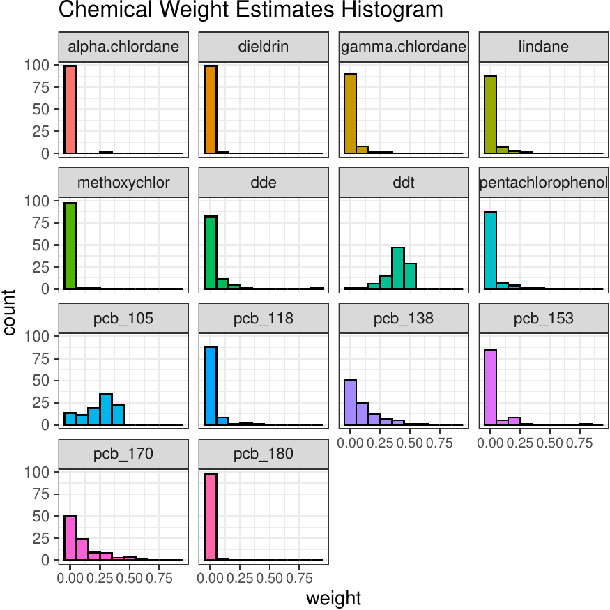

Figure 3: Histograms of chemical weight estimates across 100 bootstraps for Example 1 to select important chemicals. Weight estimates are constrained to be between zero and one.

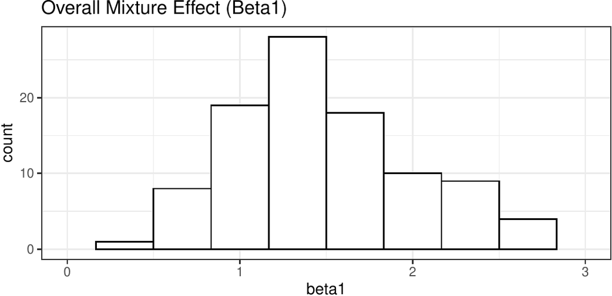

The third histogram shows us the distribution of the weighted quantile sum. Given constraints placed on the weights, WQS is a continuous index between zero and the number of quantiles minus 1 (given by the `n.quantiles` argument in `estimate.wqs()` ) (Figure 5). In our example, the number of quantiles is four. Across the bootstrap samples, most values of the chemical mixture are between one and two.

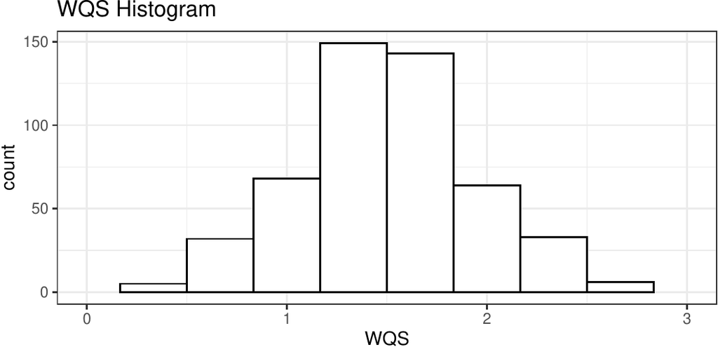

Figure 5: Histogram of the weighted quantile sum (WQS) using validation quantiles for Example 1 to show where most values of the chemical mixture lie.

# Example 2: BDLQ1 approach on interval-censored data

## BDLQ1 approach

Unlike Example 1, many studies contain partially observed chemical concentrations that are measured to different detection limits. One approach to use WQS with missing data is to place the BDL values into the first quantile (BDLQ1), and to score the observed component values in the remaining quantiles. The `make.quantile.matrix()` function demonstrates this approach by creating `n.quantiles` quantiles from a matrix argument `X`. If `X` is completely observed, regular quantiles are made; however, if the first values in `X` are missing, they are placed in the first quantile. For example, suppose we are interested in making four quantiles of 14 chemicals using 1,000 subjects in our dataset. If we use the completely observed concentrations found in `X.true` element of `simdata87`, regular quantiles for all 14 chemicals are made with the following number of individuals per quantile.

```r
> q <- make.quantile.matrix(
+   X = simdata87$X.true,
+   n.quantiles = 4
+   )
```

```
#> No missing values in matrix detected. Regular quantiles computed.
```

```r
> apply(q, 2, table)
```

```r
  [,1] [,2] [,3] [,4] [,5] [,6] [,7] [,8] [,9] [,10] [,11] [,12] [,13] [,14]
0  250  250  250  250  250  250  250  250  250   250   250   250   250   250
1  250  250  250  250  250  250  250  250  250   250   250   250   250   250
2  250  250  250  250  250  250  250  250  250   250   250   250   250   250
3  250  250  250  250  250  250  250  250  250   250   250   250   250   250
```

However, if the chemical concentrations are incomplete (with the missing values indicated as `NA`’s), the BDLQ1 approach works as follows. Suppose we wish to make quartiles of the `X.bdl` matrix in our dataset, where each chemical has 100 BDL concentrations. Using BDLQ1, the 100 observations are placed into the first quartile, and the remaining quartiles are evenly split in which each contains 900/3 = 300 observations. The number of individuals in each quartile of each chemical, and the total number of missing values in each chemical are shown below. Note that the first row of the matrix matches the total number of missing values (100).

```r
> q <- make.quantile.matrix(
+   simdata87$X.bdl,
+   n.quantiles = 4,
+   verbose = TRUE
+   )
```

```
#> All BDLs are placed in the first quantile
```

```r
##> Summary of Quantiles
  [,1] [,2] [,3] [,4] [,5] [,6] [,7] [,8] [,9] [,10] [,11] [,12] [,13] [,14]
0  100  100  100  100  100  100  100  100  100   100   100   100   100   100
1  300  300  300  300  300  300  300  300  300   300   300   300   300   300
2  300  300  300  300  300  300  300  300  300   300   300   300   300   300
3  300  300  300  300  300  300  300  300  300   300   300   300   300   300
##> Total Number of NAs--Q1 (The first row) should match.
100 100 100 100 100 100 100 100 100 100 100 100 100 100
```

The number of individuals in the first quantile in BDLQ1 increases if more BDL values exist. For instance, `X.80` substitutes 800 values for each chemical from `simdata87$X.true` to be missing BDL. Applying the BDLQ1 approach to `X.80`, all 800 values are placed into the first quartile, while roughly $200/3 \approx 66$ values are placed in remaining quartiles.

```r
> q <- make.quantile.matrix(X.80, n.quantiles = 4, verbose = TRUE)
```

```
#> All BDLs are placed in the first quantile
```

```r
##> Summary of Quantiles
  [,1] [,2] [,3] [,4] [,5] [,6] [,7] [,8] [,9] [,10] [,11] [,12] [,13] [,14]
0  800  800  800  800  800  800  800  800  800   800   800   800   800   800
1   67   67   67   67   67   67   67   67   67    67    67    67    67    67
2   66   66   66   66   66   66   66   66   66    66    66    66    66    66
3   67   67   67   67   67   67   67   67   67    67    67    67    67    67
##> Total Number of NAs--Q1 (The first row) should match.
800 800 800 800 800 800 800 800 800 800 800 800 800 800
```

Instead of quantiles, we could also categorize the chemicals into deciles by changing the `n.quantiles` argument to ten. Suppose now that we wish to form deciles in `simdata87$X.bdl`. The first 100 BDL values are placed in the first decile, while the remaining 900 are evenly spread out in the remaining nine deciles (900/9 = 100).

```r
> q <- make.quantile.matrix(simdata87$X.bdl, n.quantiles = 10, verbose = TRUE)
```

```
#> All BDLs are placed in the first quantile
```

```r
##> Summary of Quantiles
  [,1] [,2] [,3] [,4] [,5] [,6] [,7] [,8] [,9] [,10] [,11] [,12] [,13] [,14]
0  100  100  100  100  100  100  100  100  100   100   100   100   100   100
1  100  100  100  100  100  100  100  100  100   100   100   100   100   100
2  100  100  100  100  100  100  100  100  100   100   100   100   100   100
3  100  100  100  100  100  100  100  100  100   100   100   100   100   100
4  100  100  100  100  100  100  100  100  100   100   100   100   100   100
5  100  100  100  100  100  100  100  100  100   100   100   100   100   100
6  100  100  100  100  100  100  100  100  100   100   100   100   100   100
7  100  100  100  100  100  100  100  100  100   100   100   100   100   100
8  100  100  100  100  100  100  100  100  100   100   100   100   100   100
9  100  100  100  100  100  100  100  100  100   100   100   100   100   100
##> Total Number of NAs--Q1 (The first row) should match.
100 100 100 100 100 100 100 100 100 100 100 100 100 100
```

The BDLQ1 method has been used in single-chemical analyses (Metayer et al. 2013; Ward et al. 2014, 2009) and WQS (Hargarten and Wheeler 2020). However, it has not been coded in other WQS packages to the best of our knowledge.

## WQS analysis

The BDLQ1 method works because WQS regression uses quantile scores from each chemical in the mixture. At this step, the `estimate.wqs()` function calls the `make.quantile.matrix()` function. Setting the argument `place.bdls.in.Q1` to `TRUE` allows us to use the WQS regression in conjunction with the BDLQ1 method. Yet, if the `X` argument contains any missing values, the BDLQ1 approach is automatically used. The incomplete data `X.bdl` is now assigned to the chemical mixture `X` argument. The remaining arguments in `estimate.wqs()` are the same as in Example 1. Printing the resulting object answers the research questions of interest. The research aims are to determine the association of the mixture with cancer and to find the important chemicals (if the association exists).

```r
> set.seed(50679)
> wqs.BDL <- estimate.wqs(
+   y = simdata87$y.scenario, X = simdata87$X.bdl, Z = simdata87$Z.sim,
+   proportion.train = 0.5,
+   n.quantiles = 4,
+   place.bdls.in.Q1 = TRUE,
+   B = 100,
+   b1.pos = TRUE,
+   signal.fn = "signal.converge.only",
+   family = "binomial",
+   verbose = FALSE
+ )
```

```
#> All BDLs are placed in the first quantile
```

```r
> wqs.BDL
```

```r
Odd Ratios & 95% CI (N.valid = 500)
                     Odds Ratio  SE.OR                95% CI  P-value
(Intercept)               0.214   1.52  0.214 (0.094, 0.483)   <0.001
Age                       0.952   1.05  0.952 (0.858, 1.057)    0.356
Female                    0.926   1.21  0.926 (0.636, 1.349)    0.688
Hispanic                  1.560   1.22  1.558 (1.052, 2.306)    0.027
Non.Hispanic_Others       1.050   1.24  1.052 (0.687, 1.612)    0.816
WQS                       2.360   1.21  2.358 (1.626, 3.420)   <0.001
AIC:  677.0172

1 bootstrap(s) have failed to converged. Those are:
[1] 60

 Weights Adjusted by signal.converge.only using N.train = 500 observations:
          pcb_105  pentachlorophenol    gamma.chlordane    alpha.chlordane
           0.2575             0.2548             0.1622             0.0699
          pcb_153            pcb_138                ddt            lindane
           0.0658             0.0606             0.0378             0.0349
     methoxychlor            pcb_118                dde            pcb_170
           0.0180             0.0128             0.0075             0.0066
         dieldrin            pcb_180
           0.0065             0.0051
Important chemicals defined as mean weights > 1/14~0.071.
```

# Example 3: Bootstrapping interval-censored data

```r
> set.seed(472195)
> answer <- impute.Lubin(
+   chemcol = simdata87$X.bdl[, 1],
+   dlcol = simdata87$DL[1],
+   Z = cbind(simdata87$y.scenario, simdata87$Z.sim),
+   K = 2
+ )
> summary(answer$imputed_values)
```

```r
     Imp.1              Imp.2
 Min.   :       0   Min.   :       0
 1st Qu.:      11   1st Qu.:      11
 Median :     125   Median :     125
 Mean   :   44099   Mean   :   44099
 3rd Qu.:    1682   3rd Qu.:    1682
 Max.   :17354723   Max.   :17354723
```

```r
> cat("Summary of BDL Values \n")
> imp <- answer$imputed_values[, 1] < simdata87$DL[1]
> summary(answer$imputed_values[imp, ])
```

```r
Summary of BDL Values
     Imp.1             Imp.2
 Min.   :0.00124   Min.   :0.001417
 1st Qu.:0.04579   1st Qu.:0.057819
 Median :0.22420   Median :0.201560
 Mean   :0.32314   Mean   :0.272618
 3rd Qu.:0.59102   3rd Qu.:0.444859
 Max.   :0.91690   Max.   :0.854974
```

More than one chemical often needs to be imputed in many studies. To implement the bootstrap approach, we use the `impute.boot()` function, which repeatedly executes the `impute.Lubin()` function. In `simdata87`, now suppose that we wish to impute the `X.bdl` matrix twice by bootstrapping using the covariates (`Z`) of age, sex, and race/ethnicity. The `X` argument takes a matrix with incomplete data, like `simdata87$X.bdl`. The next argument, `DL`, takes the detection limits of `X` as a numeric vector, like `simdata87$DL`. The `K` and `Z` arguments are exactly the same as in `impute.Lubin()`. A seed is set before the function to ensure that the same bootstrap samples are selected for each chemical. The function returns a list `l.boot`.

```r
> set.seed(472195)
> l.boot <- impute.boot(
+   X = simdata87$X.bdl,
+   DL = simdata87$DL,
+   Z = cbind(simdata87$y.scenario, simdata87$Z.sim),
+   K = 2
+   )
```

```
#> Check: The total number of imputed values that are above the detection limit is 0.
```

```r
> results.Lubin <- l.boot$X.imputed
```

The `X.imputed` element of `l.boot` saves the imputed chemical values as an array, where the first dimension is the number of subjects ($n$), the second is the number of chemicals ($c$), and the third is the number of imputed datasets ($K$). The sample minima, fifth percentile (`P.5`), means, and maxima of the chemicals are calculated in each imputed dataset (by the function `f()`). As the two imputed datasets are different, the application of MI should yield different parameter estimates.

```r
> apply(results.Lubin, 2:3, f)
```

```r
, , Imp.1

     alpha-chlordane     dieldrin gamma-chlordane   lindane methoxychlor
min     1.239744e-03 5.214163e-02        14.85745  3.122209     16.13658
P.5     2.257984e-01 2.016689e+00        25.79766  7.147067     35.19478
mean    4.409885e+04 4.331448e+02        49.38257 17.214769     83.45674
max     1.735472e+07 4.867330e+04       139.33689 75.360498    316.07141
              dde        ddt pentachlorophenol     pcb_105     pcb_118
min  4.500939e-02   1.532625          1.604183   0.1372503   0.4547588
P.5  8.736265e-01   3.544432          3.923535   1.1031301   1.4373202
mean 2.546607e+03  16.122825         20.262419  16.4815577   9.7025958
max  3.835674e+05 178.853960        285.229348 400.3601114 142.2619560
          pcb_138      pcb_153     pcb_170     pcb_180
min    0.08042499   0.03363274   0.7155792   0.1741525
P.5    0.80147195   0.47230663   2.5599230   0.7335900
mean  12.63094227  13.82089093  11.6125246   8.4248157
max  269.09903138 383.79850341 115.2060922 203.8593938

, , Imp.2

     alpha-chlordane     dieldrin gamma-chlordane   lindane methoxychlor
min     1.417111e-03     0.117659        14.57128  3.690147     15.35223
P.5     2.024978e-01     2.276511        25.50909  6.751412     36.11395
mean    4.409884e+04   433.153356        49.36521 17.201076     83.39251
max     1.735472e+07 48673.296171       139.33689 75.360498    316.07141
              dde         ddt pentachlorophenol     pcb_105     pcb_118
min  3.502864e-02   0.9292443          1.299465   0.1512212   0.4144885
P.5  9.079915e-01   3.3656892          3.959147   1.0578307   1.3154884
mean 2.546614e+03  16.1134725         20.250618  16.4788855   9.6934267
max  3.835674e+05 178.8539599        285.229348 400.3601114 142.2619560
         pcb_138      pcb_153     pcb_170      pcb_180
min    0.2291489   0.08258941   0.4825019   0.05475401
P.5    0.8403295   0.52882557   2.5113298   0.69996133
mean  12.6359530  13.82390718  11.6064361   8.42308671
max  269.0990314 383.79850341 115.2060922 203.85939377
```

Next, we implement WQS regression on the two complete datasets, which are saved in the `results.Lubin` object. Instead of performing WQS on one dataset as in Examples 1 and 2, the `do.many.wqs()` function repeatedly executes WQS regression on each dataset. The arguments for the `do.many.wqs()` function are the same as the `estimate.wqs()` function, with one exception. The `X.imputed` argument now is an array of the imputed chemical values, which has three dimensions: *n* subjects, *c* chemicals, and *K* imputed datasets. This array is the output from the `impute.boot()` function: `results.Lubin`.

```r
> set.seed(50679)
> boot.wqs <- do.many.wqs(
+   y = simdata87$y.scenario, X.imputed = results.Lubin, Z = simdata87$Z.sim,
+   proportion.train = 0.5,
+   n.quantiles = 4,
+   B = 100,
+   b1.pos = TRUE,
+   signal.fn = "signal.converge.only",
+   family = "binomial"
+ )
```

```
#> Sample size: 1000; Number of chemicals: 14;
```

```r
Number of completed datasets: 2; Number of covariates modeled:  4
```

The `do.many.wqs()` function returns list and matrix versions of the output generated from the `estimate.wqs()` function. The `wqs.imputed.estimates` element of the `boot.wqs` list is a three-dimensional array that gives the WQS estimates for each imputed dataset. The first dimension consists of the total number parameters in the WQS model. The second dimension consists of two columns: the mean and standard deviation of estimates. The third dimension is the *K* imputation draws.

```r
> formatC(boot.wqs$wqs.imputed.estimates, format = "fg", flag = "#", digits = 3)
```

```r
, , Imputed.1

                    Estimate  Std.Error
alpha.chlordane     "0.00285" "0.0285"
dieldrin            "0.00139" "0.0101"
gamma.chlordane     "0.0138"  "0.0442"
lindane             "0.0200"  "0.0525"
methoxychlor        "0.00429" "0.0244"
dde                 "0.0339"  "0.104"
ddt                 "0.391"   "0.0936"
pentachlorophenol   "0.0216"  "0.0628"
pcb_105             "0.241"   "0.129"
pcb_118             "0.0217"  "0.0697"
pcb_138             "0.101"   "0.131"
pcb_153             "0.0344"  "0.0986"
pcb_170             "0.110"   "0.149"
pcb_180             "0.00236" "0.0114"
(Intercept)         "-1.95"   "0.415"
Age                 "-0.0516" "0.0540"
Female              "-0.0546" "0.195"
Hispanic            "0.456"   "0.204"
Non.Hispanic_Others "0.0333"  "0.221"
WQS                 "1.30"    "0.222"

, , Imputed.2

                    Estimate  Std.Error
alpha.chlordane     "0.00424" "0.0185"
dieldrin            "0.0392"  "0.0801"
gamma.chlordane     "0.00843" "0.0257"
lindane             "0.00191" "0.0119"
methoxychlor        "0.0103"  "0.0518"
dde                 "0.0767"  "0.114"
ddt                 "0.148"   "0.159"
pentachlorophenol   "0.272"   "0.163"
pcb_105             "0.156"   "0.114"
pcb_118             "0.0102"  "0.0302"
pcb_138             "0.213"   "0.193"
pcb_153             "0.0136"  "0.0513"
pcb_170             "0.0180"  "0.0526"
pcb_180             "0.0291"  "0.0625"
(Intercept)         "-1.70"   "0.363"
Age                 "0.0367"  "0.0539"
Female              "-0.199"  "0.192"
Hispanic            "0.577"   "0.200"
Non.Hispanic_Others "0.235"   "0.223"
WQS                 "0.762"   "0.163"
```

As expected, the weights and WQS parameter estimates are different across the two imputed datasets. Finally, the `pool.mi()` function implements the pooling rules discussed in Rubin 1987 (Rubin 1987) in order to form one estimate (Dong and Peng 2013; Rubin 1987; White, Royston, and Wood 2011). The `to.pool` argument takes an array with rows referring to the number of parameters, columns referring to the mean and standard error, and the third dimension referring to the number of imputed datasets. This describes the WQS output, `boot.wqs$wqs.imputed.estimates`, from the `do.many.wqs()` function. The second argument of `pool.mi()`, `n`, is the sample size, which is the number of rows in original data (i.e. `nrow(simdata87$X.bdl)`). The additional Boolean argument `prt` allows the user to print out selective parts of the `pool.mi` object, if desired.

```r
> boot.est <- pool.mi(
+   to.pool = boot.wqs$wqs.imputed.estimates,
+   n = nrow(simdata87$X.bdl),
+   prt = FALSE
+ )
```

```
#> Pooling estimates from 2 imputed analyses for 20 parameters.
```

```r
                    pooled.mean pooled.total.se se.within se.between
alpha.chlordane           0.004           0.024     0.024      0.001
dieldrin                  0.020           0.066     0.057      0.027
gamma.chlordane           0.011           0.036     0.036      0.004
lindane                   0.011           0.041     0.038      0.013
methoxychlor              0.007           0.041     0.041      0.004
dde                       0.055           0.115     0.109      0.030
ddt                       0.269           0.247     0.130      0.172
pentachlorophenol         0.147           0.250     0.123      0.177
pcb_105                   0.198           0.143     0.122      0.061
pcb_118                   0.016           0.055     0.054      0.008
pcb_138                   0.157           0.191     0.165      0.079
pcb_153                   0.024           0.081     0.079      0.015
pcb_170                   0.064           0.137     0.112      0.065
pcb_180                   0.016           0.051     0.045      0.019
(Intercept)              -1.828           0.447     0.390      0.178
Age                      -0.007           0.094     0.054      0.062
Female                   -0.127           0.230     0.193      0.102
Hispanic                  0.517           0.228     0.202      0.086
Non.Hispanic_Others       0.134           0.282     0.222      0.143
WQS                       1.030           0.504     0.195      0.379
                    frac.miss.info   CI.1   CI.2 p.value
alpha.chlordane              0.005 -0.044  0.051   0.883
dieldrin                     0.327 -0.119  0.160   0.762
gamma.chlordane              0.019 -0.060  0.083   0.761
lindane                      0.181 -0.072  0.094   0.791
methoxychlor                 0.019 -0.073  0.087   0.859
dde                          0.125 -0.174  0.284   0.632
ddt                          0.836 -0.850  1.388   0.395
pentachlorophenol            0.859 -1.099  1.393   0.624
pcb_105                      0.359 -0.109  0.506   0.187
pcb_118                      0.037 -0.091  0.123   0.770
pcb_138                      0.337 -0.250  0.564   0.424
pcb_153                      0.057 -0.135  0.183   0.766
pcb_170                      0.454 -0.249  0.378   0.652
pcb_180                      0.273 -0.089  0.120   0.759
(Intercept)                  0.314 -2.770 -0.885   0.001
Age                          0.795 -0.373  0.358   0.943
Female                       0.392 -0.631  0.378   0.593
Hispanic                     0.276  0.044  0.989   0.034
Non.Hispanic_Others          0.509 -0.538  0.807   0.650
WQS                          0.919 -2.441  4.501   0.233
```

```r
> chemicals <- boot.est[1:14, ]
> row.names(chemicals)[chemicals$pooled.mean >= 1 / 14]
```

```r
[1] "ddt"               "pentachlorophenol" "pcb_105"
[4] "pcb_138"
```

We can also obtain an overall sense of how WQS model fits the data from bootstrapping imputation. In a similar spirit in combining the WQS parameter estimates, we combine the AIC from the two models. The `combine.AIC()` function takes the average and standard deviation of the individual AIC estimates from the separate WQS models. The only argument, `AIC`, takes a numeric vector of AIC’s, which is saved in a `do.many.wqs()` object (eg. `boot.wqs$AIC`).

```r
> boot.wqs$AIC
```

```r
[1] 660.7468 665.1193
```

```r
> boot.AIC <- combine.AIC(boot.wqs$AIC)
```

# Example 4: Univariate Bayesian multiple imputation of BDL values

Instead of using bootstrapping imputation, the `impute.univariate.bayesian.mi()` imputes the BDL values using a Bayesian paradigm. The logs of the observed chemicals $x_{\text{ij}}$ are assumed to independently follow normal distributions with mean $\mu_{j}$ and standard error $\sigma_{j}$. We place a Jeffrey’s prior of the univariate normal on the parameters. In order to sample from the posterior predictive density of missing values ($X_{j,\text{miss}}$) given the observed values ($X_{j,\text{obs}}$), we run a Gibbs sampler of length $T$ for each chemical. In step $t$ of the sampler:

(Step 0): Given complete data $X = (X_{\text{miss}}^{(t-1)}, X_{\text{obs}})$, calculate the mean $\bar w$ and variance $S$ as:
$$\bar w
= \frac{1}{n} \cdot \sum_{i=1}^n \log \left(x_i \right) \; \text{and} \;
S = \frac{1}{n-1} \cdot \sum_{i=1}^n \left(\log(x_i) - \bar w \right)^2
.$$

(Step 1): Simulate the posterior variance ${\sigma^2}^{(t)}$ given the mean and complete data from the inverse gamma distribution:
$$\sigma^2|\mu^{(t-1)}, \log \left(X_{obs} \right),
\log \left(X_{miss}^{(t-1)} \right) \sim IG \left(
\frac{n-1}{2}, \frac{n-1}{2}*S \right).$$

(Step 2): Simulate the posterior mean $\mu^{(t)}$ given the variance and complete data from the normal distribution:
$$\mu |
{\sigma^2}^{(t)}, \log \left(X_{obs} \right), \log
\left(X_{miss}^{(t-1)} \right) \sim N \left(\bar w, sd =
\frac{\sigma^{(t)}}{\sqrt{n}} \right).$$

(Step 3): Using current parameter estimates, impute $\log(X_{miss,i}^{(t)})$ from the normal distribution truncated between 0 and $DL_{j}$, or:
$$\log \left( X_{miss,i} \right )|
\mu^{(t)},{\sigma^2}^{(t)} \sim TruncNorm
\left(\mu^{(t)},{\sigma^2}^{(t)}, a = 0, b = DL_j \right).$$
for $i = 1 \cdots n_{0j}$, where $n_{0j}$ is the total number of BDL values for the *jth* chemical. We assessed convergence using Gelman-Rubin’s $R$ statistics (Gelman and Rubin 1992). To construct approximately independent sets of complete concentrations, we join the observed values with the imputed values taken every tenth state from the end of the missing value chain. This Gibbs Sampler is repeated for all chemicals.

The `impute.univariate.bayesian.mi()` function applies this Bayesian algorithm to our dataset. The `X` argument takes a matrix with incomplete data, like `simdata87$X.bdl`. The `DL` argument takes the detection limits of `X`, which must be a numeric vector, like `simdata87$DL`. Bayesian imputation currently does not use covariate information. The `T` argument specifies the length of the Gibbs sampler (like `6000`), and the `n.burn` argument specifies the burn-in (like `400`). The `K` argument gives the number of imputed datasets generated (like `2`). The `impute.univariate.bayesian.mi()` function returns a list consisting of three categories: a series of checks, the imputed array, and the MCMC (Markov chain Monte Carlo) chains.

```r
> set.seed(472195)
> result.imputed <- impute.univariate.bayesian.mi(
+   X = simdata87$X.bdl,
+   DL = simdata87$DL,
+   T = 6000,
+   n.burn = 400,
+   K = 2
+ )
```

```
#> Start MCMC Data Augmentation Algorithm...
```

```
#> Checking for convergence with 2nd chain ...
```

```r
  gelman.stat     is.converge
 Min.   :0.9998   Mode:logical
 1st Qu.:1.0001   TRUE:1428
 Median :1.0004
 Mean   :1.0010
 3rd Qu.:1.0013
 Max.   :1.0182
```

```
#> Evidence suggests that all 1428 parameters have converged.
#> Draw 2 Multiple Imputed Set(s) from states
```

```r
[1] 6000 5990
```

```
#> Check: Indicator of # of missing values above detection limit
```

```r
[1] 0
```

The `impute.univariate.bayesian.mi()` function returns a check of convergence in `convg.table` and a check of correct imputation in `indicator.miss`. To check for convergence, a summary of a data frame `convg.table` is shown above. The first column consists of the Gelman-Rubin statistics of the MCMC variables. (In the dataset `simdata87`, there are $(100+2)*14 = 1428$ MCMC variables, as each chemical has 102 MCMC variables: 100 missing values, mean, and variance.) The `is.converge` column of `convg.table` is a logical vector that specifies whether each MCMC variable has converged. This occurs if its Gelman-Rubin statistic is less than 1.1. In our example, the chains give evidence of convergence. The `"Indicator of # missing values above the detection limit"` shown above, represented with `indicator.miss`, is included to check if the imputation scheme occurred correctly. It should be zero, which it is shown above. The `indicator.miss` sums a logical vector of length $c$, in which an entry is TRUE if the imputed values are above the detection limit.

The element `X.imputed` of `result.imputed` list saves the imputed chemical values as an array, where the first dimension is the number of subjects ($n$), the second is the number of chemicals ($c$), and the third is the number of imputed datasets generated ($K$). Sample minima, means, and maxima (calculated by function `f()`) between two imputed datasets indicate that datasets are different; so when MI is applied, the parameter estimates should be different. Note that low values from Bayesian imputation differ from low bootstrap values as in Example 3.

```r
> apply(result.imputed$X.imputed, 2:3, f)
```

```r
, , Imputed.1

     alpha-chlordane     dieldrin gamma-chlordane   lindane methoxychlor
min     2.359430e-03 3.086685e-01        1.691056  1.215282     1.540713
P.5     5.242831e-01 3.183691e+00        3.610778  2.600923     4.182447
mean    4.409886e+04 4.332269e+02       47.283406 16.800662    80.420552
max     1.735472e+07 4.867330e+04      139.336894 75.360498   316.071414
              dde        ddt pentachlorophenol      pcb_105      pcb_118
min  2.768024e-02   0.482848         0.7046569   0.09017045   0.09142874
P.5  1.543214e+00   2.237090         2.7680096   1.16068653   1.30752584
mean 2.546653e+03  16.013644        20.1570964  16.48534459   9.68569878
max  3.835674e+05 178.853960       285.2293482 400.36011141 142.26195601
          pcb_138      pcb_153     pcb_170      pcb_180
min    0.01173117   0.02468827   0.7360772 2.164636e-03
P.5    0.68685631   0.38681360   2.0959549 5.996663e-01
mean  12.61938196  13.81475010  11.5772453 8.412071e+00
max  269.09903138 383.79850341 115.2060922 2.038594e+02

, , Imputed.2

     alpha-chlordane     dieldrin gamma-chlordane   lindane methoxychlor
min     8.514882e-03 4.098326e-01        1.462564  1.089740     1.425771
P.5     4.664125e-01 3.332290e+00        3.418596  2.638882     4.321919
mean    4.409886e+04 4.332296e+02       47.258091 16.797956    80.424921
max     1.735472e+07 4.867330e+04      139.336894 75.360498   316.071414
              dde         ddt pentachlorophenol      pcb_105      pcb_118
min  5.568180e-02   0.9352681          0.297144 3.085055e-03 5.716621e-03
P.5  1.580193e+00   2.5371056          2.670481 1.110512e+00 1.215440e+00
mean 2.546663e+03  16.0346907         20.148387 1.648278e+01 9.684614e+00
max  3.835674e+05 178.8539599        285.229348 4.003601e+02 1.422620e+02
          pcb_138      pcb_153     pcb_170      pcb_180
min  9.471776e-03 3.198244e-03   0.5399104   0.00652091
P.5  7.249506e-01 4.114339e-01   2.1037311   0.58501721
mean 1.262209e+01 1.381682e+01  11.5786930   8.41077395
max  2.690990e+02 3.837985e+02 115.2060922 203.85939377
```

The `impute.univariate.bayesian.mi()` function also returns the three entire MCMC chains: the means of components, the standard errors, and the imputed missing values. The [*coda*](https://CRAN.R-project.org/package=coda) package, which “provides functions for summarizing and plotting the output from … MCMC simulations”, saved these MCMC chains as `MCMC` objects (Plummer et al. 2006).

Using the imputed datasets saved in array `result.imputed$X.imputed`, the `do.many.wqs()` function implements WQS regression on both datasets with a binary outcome, as in Example 3. The setup is the same as before, but we are using Bayesian imputed datasets, as in `result.imputed$X.imputed`. Similar to Example 3, the element, `wqs.imputed.estimates`, in the resulting `bayes.wqs` list contains the WQS parameter estimates for each imputed dataset.

```r
> set.seed(50679)
> bayes.wqs <- do.many.wqs(
+   y = simdata87$y.scenario, X.imputed = result.imputed$X.imputed,
+   Z = simdata87$Z.sim,
+   proportion.train = 0.5,
+   n.quantiles = 4,
+   B = 100,
+   b1.pos = TRUE,
+   signal.fn = "signal.converge.only",
+   family = "binomial"
+ )
> wqs.imputed.estimates <- bayes.wqs$wqs.imputed.estimates
```

```
#> Sample size: 1000; Number of chemicals: 14;
```

```r
Number of completed datasets: 2; Number of covariates modeled:  4
```

```r
> bayesian.est <- pool.mi(
+   to.pool = bayes.wqs$wqs.imputed.estimates,
+   n = nrow(simdata87$X.bdl),
+   prt = TRUE
+ )
```

```
#> Pooling estimates from 2 imputed analyses for 20 parameters.
```

```r
                    pooled.mean pooled.total.se frac.miss.info   CI.1   CI.2
alpha.chlordane           0.004           0.024          0.005 -0.044  0.051
dieldrin                  0.020           0.066          0.327 -0.119  0.160
gamma.chlordane           0.011           0.036          0.019 -0.060  0.083
lindane                   0.011           0.041          0.181 -0.072  0.094
methoxychlor              0.007           0.041          0.019 -0.073  0.087
dde                       0.055           0.115          0.125 -0.174  0.284
ddt                       0.269           0.247          0.836 -0.850  1.388
pentachlorophenol         0.147           0.250          0.859 -1.099  1.393
pcb_105                   0.198           0.143          0.359 -0.109  0.506
pcb_118                   0.016           0.055          0.037 -0.091  0.123
pcb_138                   0.157           0.191          0.337 -0.250  0.564
pcb_153                   0.024           0.081          0.057 -0.135  0.183
pcb_170                   0.064           0.137          0.454 -0.249  0.378
pcb_180                   0.016           0.051          0.273 -0.089  0.120
(Intercept)              -1.828           0.447          0.314 -2.770 -0.885
Age                      -0.007           0.094          0.795 -0.373  0.358
Female                   -0.127           0.230          0.392 -0.631  0.378
Hispanic                  0.517           0.228          0.276  0.044  0.989
Non.Hispanic_Others       0.134           0.282          0.509 -0.538  0.807
WQS                       1.030           0.504          0.919 -2.441  4.501
                    P.value
alpha.chlordane       0.883
dieldrin              0.762
gamma.chlordane       0.761
lindane               0.791
methoxychlor          0.859
dde                   0.632
ddt                   0.395
pentachlorophenol     0.624
pcb_105               0.187
pcb_118               0.770
pcb_138               0.424
pcb_153               0.766
pcb_170               0.652
pcb_180               0.759
(Intercept)          <0.001
Age                   0.943
Female                0.593
Hispanic              0.034
Non.Hispanic_Others   0.650
WQS                   0.233
```

Looking at the WQS estimate in `bayesian.est`, the odds ratio of the overall chemical mixture on cancer is 2.8 with a 95% confidence interval between 0.09 and 90.15. The following chemicals, in which their weight estimates are greater than 1/14, are considered an important and may be associated with increased cancer risk.

```r
> chemicals <- bayesian.est[1:14, ]
> row.names(chemicals)[chemicals$pooled.mean >= 1 / 14]
```

```r
[1] "ddt"               "pentachlorophenol" "pcb_105"
[4] "pcb_138"
```

To get an overall sense of how the Bayesian-imputed WQS models fit the data, the `combine.AIC()` function combines the AIC calculated from Bayesian MI-WQS models (`bayes.wqs$AIC`).

```r
> bayes.wqs$AIC
```

```r
[1] 660.7468 665.1193
```

```r
> miWQS::combine.AIC(bayes.wqs$AIC)
```

```r
[1] "662.9 +- 3.1"
```

The Bayesian MI-WQS model (AIC: 662.9 +- 3.1) has the same fit as the bootstrapped MI-WQS (Example 3, AIC: 662.9 +- 3.1).

# Recommendations in using miWQS package

We have integrated WQS regression into the MI framework in a flexible R package called *miWQS* to meet a wide variety of needs (Figure 6). The data used in this package consist of a mixture of correlated components that share a common outcome while adjusting for other covariates. The correlated components in the set, $\boldsymbol{X}$, may be complete or interval-censored between zero and low thresholds, or detection limits, that may be different across the components. The common outcome, $y$, may be modeled as binary, continuous, count-based, or rate-based and can be adjusted by the `family` and `offset` arguments of `estimate.wqs()`.

Additional covariates, $\boldsymbol{Z}$, may be used in the bootstrap imputation and WQS models. However, the univariate Bayesian model does not include covariate information in imputing the BDL values. This makes any covariate confounders uncorrelated with the imputed concentrations BDL. Thereby, the WQS regression coefficients, such as the weights and overall mixture effect, may be biased towards zero (Forer 2014; Little 1992).

Another limitation of the univariate Bayesian and bootstrap imputation models is that the X’s are imputed independently while the actual X’s are correlated. This makes the correlations among the imputed BDL values of different components biased towards zero. One concern is that the mixture with independently imputed BDL values may introduce some bias in the health effect estimate if a large amount of BDL values is present. As an alternative, an imputation model could take advantage of the correlations to impute a potentially more precise estimate (Dong and Peng 2013; Little 1992). One such approach is the multivariate Bayesian regression imputation model, which we are evaluating in ongoing work (Hargarten and Wheeler 2020).

# Conclusion

Although environmental exposures data motivated us to develop the *miWQS* package, the package may be applied to other areas in public health and medicine. Wheeler et al. (Wheeler, Jones, et al. 2019) recently used WQS regression to estimate the effect of a SES index on childhood blood lead risk and to find which socioeconomic variables are important. The correlated SES variables considered were of these types: educational achievement, race, income, health, housing, and employment. The five most important variables found were: percent of homes built before 1940, percent of not using Social-Security income, percent of renter-occupied housing, percent unemployed, and percent of the African American population (Wheeler, Jones, et al. 2019, pg.974). Other similar studies may be analyzed using the *miWQS* package. To our knowledge, WQS has not yet been applied in analyzing a high-throughput gene expression dataset. For instance, a GWAS is conducted to find genetic risks for complex disease and to identify specific genes. Given that SNPs are correlated with each other (Ferber and Archer 2015) and a binary or continuous health outcome, the *miWQS* package may be used to conduct a WQS regression to address these research aims. In the years to come, researchers may add other imputation models to our established computational structure in order to find components that impact human health.

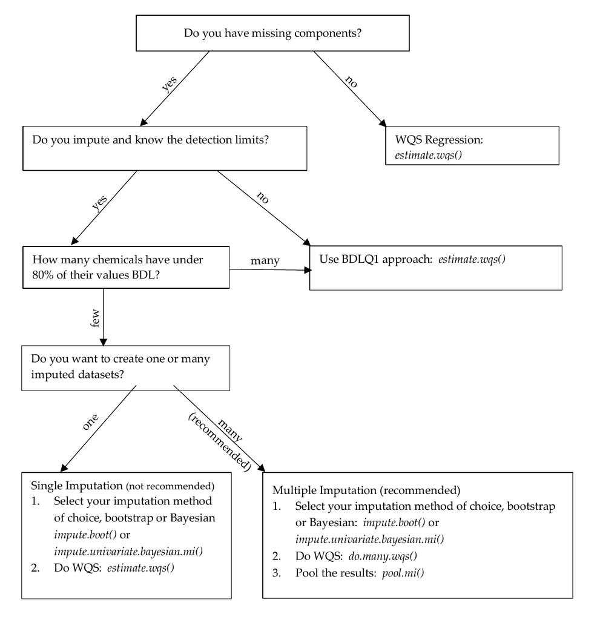

Figure 6: A decision tree to help researchers in using the miWQS package. The package is flexible and can meet a wide range of needs.